# Project: Investigate a Dataset: TMDb movie data

## Introduction

#### This dataset contains alot of useful information including but not limited to genre, user ratings and revenue, and by analzing all of this information we are going to able to find relationships between them and aquire an an insight for what dectates a successful movie.

#### We will mainly look into these following questions:

- How did different genres develop over the years regarding popularity?
- What kinds of properties are associated with movies that have high revenues?

```python
# import essensial packages
import pandas as pd
import numpy as np
import matplotlib.pyplot as plt
import seaborn as sns
%matplotlib inline
```

## Data Wrangling

### General Properties

```python
# Load  data and Perform operations to inspect data
df= pd.read_csv('tmdb-movies.csv')
df.head()
```

|  | id | imdb_id | popularity | budget | revenue | original_title | cast | homepage | director | tagline | ... | overview | runtime | genres | production_companies | release_date | vote_count | vote_average | release_year | budget_adj | revenue_adj |
| --- | --- | --- | --- | --- | --- | --- | --- | --- | --- | --- | --- | --- | --- | --- | --- | --- | --- | --- | --- | --- | --- |
| 0 | 135397 | tt0369610 | 32.985763 | 150000000 | 1513528810 | Jurassic World | Chris Pratt\|Bryce Dallas Howard\|Irrfan Khan\|Vi... | http://www.jurassicworld.com/ | Colin Trevorrow | The park is open. | ... | Twenty-two years after the events of Jurassic ... | 124 | Action\|Adventure\|Science Fiction\|Thriller | Universal Studios\|Amblin Entertainment\|Legenda... | 6/9/15 | 5562 | 6.5 | 2015 | 1.379999e+08 | 1.392446e+09 |
| 1 | 76341 | tt1392190 | 28.419936 | 150000000 | 378436354 | Mad Max: Fury Road | Tom Hardy\|Charlize Theron\|Hugh Keays-Byrne\|Nic... | http://www.madmaxmovie.com/ | George Miller | What a Lovely Day. | ... | An apocalyptic story set in the furthest reach... | 120 | Action\|Adventure\|Science Fiction\|Thriller | Village Roadshow Pictures\|Kennedy Miller Produ... | 5/13/15 | 6185 | 7.1 | 2015 | 1.379999e+08 | 3.481613e+08 |
| 2 | 262500 | tt2908446 | 13.112507 | 110000000 | 295238201 | Insurgent | Shailene Woodley\|Theo James\|Kate Winslet\|Ansel... | http://www.thedivergentseries.movie/#insurgent | Robert Schwentke | One Choice Can Destroy You | ... | Beatrice Prior must confront her inner demons ... | 119 | Adventure\|Science Fiction\|Thriller | Summit Entertainment\|Mandeville Films\|Red Wago... | 3/18/15 | 2480 | 6.3 | 2015 | 1.012000e+08 | 2.716190e+08 |
| 3 | 140607 | tt2488496 | 11.173104 | 200000000 | 2068178225 | Star Wars: The Force Awakens | Harrison Ford\|Mark Hamill\|Carrie Fisher\|Adam D... | http://www.starwars.com/films/star-wars-episod... | J.J. Abrams | Every generation has a story. | ... | Thirty years after defeating the Galactic Empi... | 136 | Action\|Adventure\|Science Fiction\|Fantasy | Lucasfilm\|Truenorth Productions\|Bad Robot | 12/15/15 | 5292 | 7.5 | 2015 | 1.839999e+08 | 1.902723e+09 |
| 4 | 168259 | tt2820852 | 9.335014 | 190000000 | 1506249360 | Furious 7 | Vin Diesel\|Paul Walker\|Jason Statham\|Michelle ... | http://www.furious7.com/ | James Wan | Vengeance Hits Home | ... | Deckard Shaw seeks revenge against Dominic Tor... | 137 | Action\|Crime\|Thriller | Universal Pictures\|Original Film\|Media Rights ... | 4/1/15 | 2947 | 7.3 | 2015 | 1.747999e+08 | 1.385749e+09 |

5 rows × 21 columns

```python
df.info()
```

```
<class 'pandas.core.frame.DataFrame'>
RangeIndex: 10866 entries, 0 to 10865
Data columns (total 21 columns):
id                      10866 non-null int64
imdb_id                 10856 non-null object
popularity              10866 non-null float64
budget                  10866 non-null int64
revenue                 10866 non-null int64
original_title          10866 non-null object
cast                    10790 non-null object
homepage                2936 non-null object
director                10822 non-null object
tagline                 8042 non-null object
keywords                9373 non-null object
overview                10862 non-null object
runtime                 10866 non-null int64
genres                  10843 non-null object
production_companies    9836 non-null object
release_date            10866 non-null object
vote_count              10866 non-null int64
vote_average            10866 non-null float64
release_year            10866 non-null int64
budget_adj              10866 non-null float64
revenue_adj             10866 non-null float64
dtypes: float64(4), int64(6), object(11)
memory usage: 1.7+ MB
```

```python
df.describe()
```

|  | id | popularity | budget | revenue | runtime | vote_count | vote_average | release_year | budget_adj | revenue_adj |
| --- | --- | --- | --- | --- | --- | --- | --- | --- | --- | --- |
| count | 10866.000000 | 10866.000000 | 1.086600e+04 | 1.086600e+04 | 10866.000000 | 10866.000000 | 10866.000000 | 10866.000000 | 1.086600e+04 | 1.086600e+04 |
| mean | 66064.177434 | 0.646441 | 1.462570e+07 | 3.982332e+07 | 102.070863 | 217.389748 | 5.974922 | 2001.322658 | 1.755104e+07 | 5.136436e+07 |
| std | 92130.136561 | 1.000185 | 3.091321e+07 | 1.170035e+08 | 31.381405 | 575.619058 | 0.935142 | 12.812941 | 3.430616e+07 | 1.446325e+08 |
| min | 5.000000 | 0.000065 | 0.000000e+00 | 0.000000e+00 | 0.000000 | 10.000000 | 1.500000 | 1960.000000 | 0.000000e+00 | 0.000000e+00 |
| 25% | 10596.250000 | 0.207583 | 0.000000e+00 | 0.000000e+00 | 90.000000 | 17.000000 | 5.400000 | 1995.000000 | 0.000000e+00 | 0.000000e+00 |
| 50% | 20669.000000 | 0.383856 | 0.000000e+00 | 0.000000e+00 | 99.000000 | 38.000000 | 6.000000 | 2006.000000 | 0.000000e+00 | 0.000000e+00 |
| 75% | 75610.000000 | 0.713817 | 1.500000e+07 | 2.400000e+07 | 111.000000 | 145.750000 | 6.600000 | 2011.000000 | 2.085325e+07 | 3.369710e+07 |
| max | 417859.000000 | 32.985763 | 4.250000e+08 | 2.781506e+09 | 900.000000 | 9767.000000 | 9.200000 | 2015.000000 | 4.250000e+08 | 2.827124e+09 |

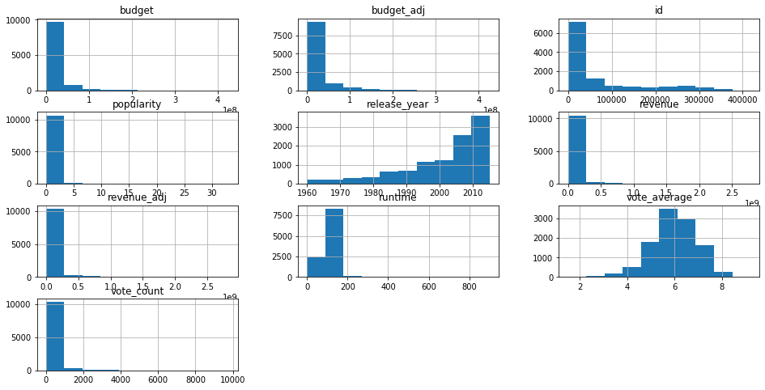

```python
df.hist(figsize=(16,8));
```

### Data Cleaning: removing unwanted columns, nulls and incorrect data

**We will keep production_companies column although it contains null data as it is very useful in the analysis process**

**We are assuming all null values in production_companies clumn are 'independent'**

```python
# Drop columns we are not going to use in our project


df.drop(['id','imdb_id','homepage','tagline','overview','keywords'],axis= 1, inplace= True)

df.production_companies.fillna('independent', inplace= True)
```

```python
# check info where runtime equals zero which is incorrect

df.query('runtime == 0').info()
```

```
<class 'pandas.core.frame.DataFrame'>
Int64Index: 31 entries, 92 to 8874
Data columns (total 15 columns):
popularity              31 non-null float64
budget                  31 non-null int64
revenue                 31 non-null int64
original_title          31 non-null object
cast                    31 non-null object
director                29 non-null object
runtime                 31 non-null int64
genres                  30 non-null object
production_companies    31 non-null object
release_date            31 non-null object
vote_count              31 non-null int64
vote_average            31 non-null float64
release_year            31 non-null int64
budget_adj              31 non-null float64
revenue_adj             31 non-null float64
dtypes: float64(4), int64(5), object(6)
memory usage: 3.9+ KB
```

```python
# Drop rows with runtime equals zero

df.drop(index=df.query('runtime == 0').index, inplace= True)
```

```python
# Drop rows that still contains null values

df.dropna(subset= ['cast', 'director','genres'], inplace= True)

# Convert datatype of 'release_date' column to datetime

df.release_date=pd.to_datetime(df.release_date)
mask = df.release_date.dt.year >= 2020
df.loc[mask, 'release_date'] = df.loc[mask, 'release_date'] - pd.DateOffset(years=100)
```

## Exploratory Data Analysis

### Research Question 1: How did different genres develop over the years regarding popularity?

```python
## Define function to expand columns that contain values separated by '|' such as 'genre' to correctly analyze each value

def tidy_split(df, column, sep='|', keep=False):
    """
    Split the values of a column and expand so the new DataFrame has one split
    value per row. Filters rows where the column is missing.

    Params
    ------
    df : pandas.DataFrame
        dataframe with the column to split and expand
    column : str
        the column to split and expand
    sep : str
        the string used to split the column's values
    keep : bool
        whether to retain the presplit value as it's own row

    Returns
    -------
    pandas.DataFrame
        Returns a dataframe with the same columns as `df`.
    """
    indexes = list()
    new_values = list()
    df = df.dropna(subset=[column])
    for i, presplit in enumerate(df[column].astype(str)):
        values = presplit.split(sep)
        if keep and len(values) > 1:
            indexes.append(i)
            new_values.append(presplit)
        for value in values:
            indexes.append(i)
            new_values.append(value)
    new_df = df.iloc[indexes, :].copy()
    new_df[column] = new_values
    return new_df
```

### In the following analyses, we are going to mainly use the sum of values instead of the average, as some values only appear very few times and by using the average we would account for incorrect weight of these values.

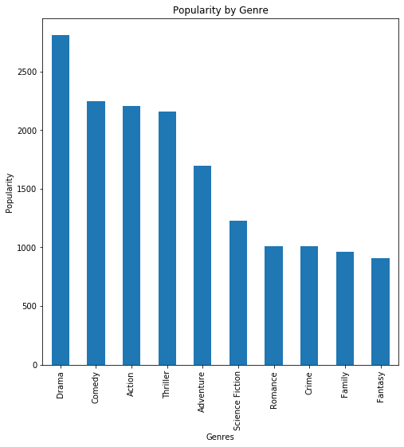

```python
# Separate different genres

df_gen= df.copy()
df_gen=tidy_split(df_gen,'genres',sep= '|')

# Sort different genres by cumulative popularity over time

top_ten=df_gen.groupby('genres').sum()[['popularity']].sort_values(by=['popularity'],ascending= False).head(10)
g= top_ten.plot(legend= False, title= 'Popularity by Genre', kind='bar', figsize=(8,8));
g.set_xlabel('Genres');
g.set_ylabel('Popularity');
```

```python
#top_ten.index
top_ten= df_gen[df_gen.genres.isin(top_ten.index)]
```

```python
# Sort movies by year
top_ten['year']= top_ten.release_date.dt.year

# Group movies by genre and year and plot development of genres over time by the cumulative popularity of movies in that genre
# for a specific year.

top_ten= top_ten.groupby(['year','genres']).sum()['popularity']
```

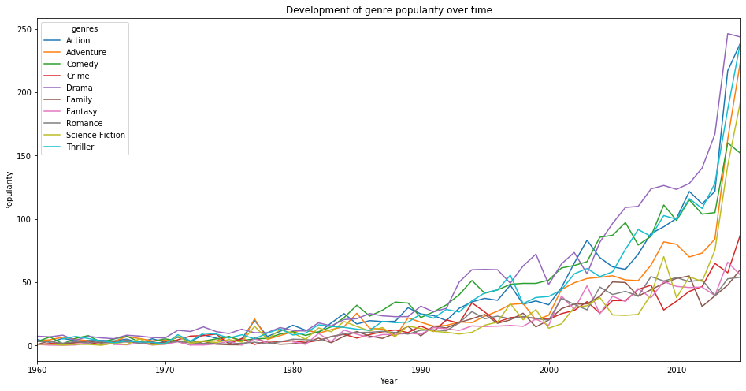

```python
g=top_ten.unstack(level= -1).plot(title= 'Development of genre popularity over time', kind='line',figsize=(16,8));
g.set_xlabel('Year');
g.set_ylabel('Popularity');
```

### Research Question 2 : What kinds of properties are associated with movies that have high revenues?

```python
(df.count()* .25)[0]
```

```
2676.0
```

```python
#Sort movies descending by the amount of revenue and using only the top 25% of those.
# Note we are using 'revenue_adj' to account for inflation.

top_25= df.sort_values(by=['revenue_adj'],ascending= False).head(2676)
top_25.info()
```

```
<class 'pandas.core.frame.DataFrame'>
Int64Index: 2676 entries, 1386 to 8314
Data columns (total 15 columns):
popularity              2676 non-null float64
budget                  2676 non-null int64
revenue                 2676 non-null int64
original_title          2676 non-null object
cast                    2676 non-null object
director                2676 non-null object
runtime                 2676 non-null int64
genres                  2676 non-null object
production_companies    2676 non-null object
release_date            2676 non-null datetime64[ns]
vote_count              2676 non-null int64
vote_average            2676 non-null float64
release_year            2676 non-null int64
budget_adj              2676 non-null float64
revenue_adj             2676 non-null float64
dtypes: datetime64[ns](1), float64(4), int64(5), object(5)
memory usage: 334.5+ KB
```

```python
150 / tidy_split(df,'director',sep= '|').director.nunique() , tidy_split(df,'director',sep= '|').director.nunique()
```

```
(0.028414472437961736, 5279)
```

```python
top_dir=top_25.copy()

# Separate different directors

top_dir=tidy_split(top_dir,'director',sep= '|')
#top_dir.info()

# Sort directors by most cumulative revenue

top_dir= top_dir.groupby('director')['revenue_adj'].sum()
top_dir= top_dir.reset_index()
#top_dir.director.unique
top_dir.sort_values(by=['revenue_adj'], ascending= False).head(150)
```

|  | director | revenue_adj |
| --- | --- | --- |
| 1050 | Steven Spielberg | 1.526692e+10 |
| 434 | James Cameron | 7.307021e+09 |
| 841 | Peter Jackson | 7.014985e+09 |
| 357 | George Lucas | 6.300795e+09 |
| 934 | Robert Zemeckis | 5.624649e+09 |
| ... | ... | ... |
| 790 | Nora Ephron | 1.124225e+09 |
| 398 | Hal Needham | 1.123731e+09 |
| 1087 | Tim Story | 1.104959e+09 |
| 320 | Frank Coraci | 1.101998e+09 |
| 444 | James Mangold | 1.100534e+09 |

150 rows × 2 columns

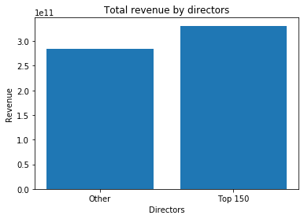

```python
top_150= top_dir.sort_values(by=['revenue_adj'], ascending= False).head(150)
i=list(top_150.director)

# Group all directors which are not in the top 150 according to revenue

rest=tidy_split(df,'director',sep= '|')
rest= rest[~rest['director'].isin(i)]

# Calculate sum of revenue for the top 150 directors and the rest

low= rest.revenue_adj.sum()
top= top_dir.sort_values(by=['revenue_adj'], ascending= False).head(150).sum()[1]

# Create a bar chart with proper labels
locations = [1, 2]
heights = [low, top]
labels = ['Other', 'Top 150']
plt.bar(locations, heights, tick_label=labels)
plt.title('Total revenue by directors')
plt.xlabel('Directors')
plt.ylabel('Revenue');
```

**The above graph shows that around 150 directors; which is as little as 3% of the total number in this dataset (5279) returned more revenue than the rest of directors combined.**

```python
150 / tidy_split(df,'production_companies',sep= '|').production_companies.nunique() , tidy_split(df,'production_companies',sep= '|').production_companies.nunique()
```

```
(0.01914486279514997, 7835)
```

```python
top_prod=top_25.copy()

# Separate different production companies

top_prod=tidy_split(top_prod,'production_companies',sep= '|')
#top_prod.info()

# Sort production companies by most cumulative revenue

top_prod= top_prod.groupby('production_companies')['revenue_adj'].sum()
top_prod= top_prod.reset_index()
top_prod.sort_values(by=['revenue_adj'], ascending= False).head(150)
```

|  | production_companies | revenue_adj |
| --- | --- | --- |
| 1954 | Warner Bros. | 6.976257e+10 |
| 1894 | Universal Pictures | 6.266217e+10 |
| 1386 | Paramount Pictures | 5.622634e+10 |
| 1864 | Twentieth Century Fox Film Corporation | 5.156992e+10 |
| 1949 | Walt Disney Pictures | 3.712252e+10 |
| ... | ... | ... |
| 1507 | Red Wagon Entertainment | 1.700604e+09 |
| 344 | Chernin Entertainment | 1.696662e+09 |
| 588 | Epsilon Motion Pictures | 1.688635e+09 |
| 209 | Big Screen Productions | 1.687729e+09 |
| 1600 | Section Eight | 1.679334e+09 |

150 rows × 2 columns

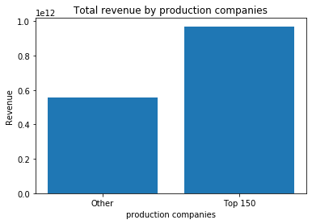

```python
top_150= top_prod.sort_values(by=['revenue_adj'], ascending= False).head(150)
i=list(top_150.production_companies)

# Group all production_companies which are not in the top 150 according to revenue

rest=tidy_split(df,'production_companies',sep= '|')

rest= rest[~rest['production_companies'].isin(i)]

# Calculate sum of revenue for the top 150 production_companies and the rest

low= rest.revenue_adj.sum()
top= top_prod.sort_values(by=['revenue_adj'], ascending= False).head(150).sum()[1]

# Create a bar chart with proper labels
locations = [1, 2]
heights = [low, top]
labels = ['Other', 'Top 150']
plt.bar(locations, heights, tick_label=labels)
plt.title('Total revenue by production companies')
plt.xlabel('production companies')
plt.ylabel('Revenue');
```

**The above graph shows that around 150 production companies; which is as little as 2% of the total number in this dataset (7835) returned more revenue than the rest of production companies combined.**

```python
500 / tidy_split(df,'cast',sep= '|').cast.nunique() , tidy_split(df,'cast',sep= '|').cast.nunique()
```

```
(0.026495681203963752, 18871)
```

```python
top_act=top_25.copy()

# Separate different actors

top_act=tidy_split(top_act,'cast',sep= '|')
#top_act.info()

# Sort actors by most cumulative revenue

top_act= top_act.groupby('cast')['revenue_adj'].sum()
top_act= top_act.reset_index()
top_act.sort_values(by=['revenue_adj'], ascending= False).head(500)
```

|  | cast | revenue_adj |
| --- | --- | --- |
| 1801 | Harrison Ford | 1.454970e+10 |
| 4715 | Tom Cruise | 1.118137e+10 |
| 4720 | Tom Hanks | 1.064438e+10 |
| 1453 | Emma Watson | 8.740437e+09 |
| 1896 | Ian McKellen | 8.620207e+09 |
| ... | ... | ... |
| 925 | Clive Owen | 1.331387e+09 |
| 3319 | Melinda Dillon | 1.328804e+09 |
| 2111 | Jason Biggs | 1.327290e+09 |
| 4494 | Steve Coogan | 1.325005e+09 |
| 1150 | David Ogden Stiers | 1.322071e+09 |

500 rows × 2 columns

[figure not shown]

```python
top_500= top_act.sort_values(by=['revenue_adj'], ascending= False).head(500)
i=list(top_500.cast)

# Group all production_companies which are not in the top 150 according to revenue

rest=tidy_split(df,'cast',sep= '|')

rest= rest[~rest['cast'].isin(i)]

# Calculate sum of revenue for the top 500 cast members and the rest

low= rest.revenue_adj.sum()
top= top_act.sort_values(by=['revenue_adj'], ascending= False).head(500).sum()[1]

# Create a bar chart with proper labels
locations = [1, 2]
heights = [low, top]
labels = ['Other', 'Top 150']
plt.bar(locations, heights, tick_label=labels)
plt.title('Total revenue by cast members')
plt.xlabel('cast members')
plt.ylabel('Revenue');
```

**The above graph shows that around 500 cast members; which is less than 3% of the total number in this dataset (18871) returned more revenue than the rest of cast members combined.**

### In the above three tables we show top directors, production companies and cast members which cumulated the most revenue for their movies.

### These numbers shows that the characteristics discussed are associated with movies with high revenue.

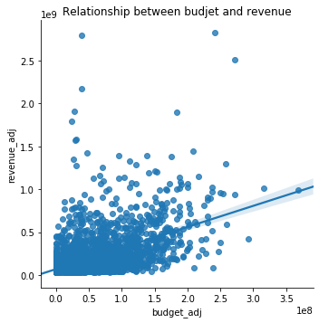

```python
#Scatter plot and regression line for the relationship between budget and revenue.

sns.lmplot(x='budget_adj',y='revenue_adj',data=top_25,fit_reg=True)
ax = plt.gca()
ax.set_title("Relationship between budjet and revenue");
```

## Limitations

#### The provided dataset includes a good portion of incorrect values such as 0 runtime, budget and revenue.Although 0 runtime values are clearly incorrect, but it is hard to tell if 0 budget and revenue values are, and there is no enough information to support either claims.

#### There is no proof that each release for each director, production comapny and cast member is listed in this dataset, and if that is the case, it may mean that results obtained here are inconclusive and may be skewed in favor to individuals or organisations listed abundantly in the dataset.

#### There is no clear definition for "Popularity" meter which may affect how we adress different questions such as the first question addressed in this report.

#### It is not made clear in the dataset if a specific director or cast member for example is playing a primary or secondary or even a cameo role in a given release, which may incorrectly favor results towards this individual. For example, a cast member having a cameo role in a given release may not have an impact on the return of that release.